# 卫师姐文章复现

XianRen Zuo

2018年9月7日

## 基于文本挖掘和自动分类的法院裁判决策支持系统设计

## **摘要**

#### 要解决的问题

不断产生的新型法律关系使得成文法无法及时制定和修改

世界各国纠纷诉讼的数目也在急剧增长，所以，很多国家面临如何在保证审判质量的前提下提高 **司法系统审判效率**的问题。

#### 本文贡献

1. 本文以中国的医疗损害诉讼文本为例，使用文本挖掘和自动分类技术提出了一个**法院裁判决策支持系统（ＣＪ－ＤＳＳ）**，该系统可以依据以往判例预测新诉讼文本的判决结果：驳回与非驳回。
2. **组合特征提取法**确实能够改进和提高分类器的分类性能，而且针对支持向量机（ＳＶＭ）、人工神经网络（ＡＮＮ）、Ｋ最近邻（ＫＮＮ）三种不同的分类器。

**文档词频－卡方（ＤＦ－ＣＨＩ）组合特征提取法**对性能的改进程度有所差异，其中ＡＮＮ的性能改进最高。

3. **集成学习**后该系统的分类性能更加稳定，显著优于单一分类器，Ｆ１值达到９３．３％。

==================================================================================================================

## 1. 引言

P1. 审判实践中积累的判例与法律规范结合可以完善法律体系。

本文就此提出法院裁判决策支持系统（CJ-DSS)

P2. 决策支持系统（DSS）的应用很广泛，主要在医疗健康领域和企业管理领域。

P3. 文本自动分类技术在专利文本上研究很成熟。

Kim 等 先对文本中的结构化信息进行聚类筛选出语义元素（Semantic elements），以此作为文本分类的基本特征，然后使用KNN（k-Nearest Neighbour）方法进行分类。实验发现，相对于未使用结构化信息的系统而言，分类效果提升了74％。

P4. 文本分类技术的各种手段

1. KNN算法是构建有效率的文本分类系统的重要手段之一
2. 支持向量机（SVM）技术能够对实验数据的类型进行识别并分类。
3. Coussement和Poel使用E-mail中的语义特征作为指标，结合传统的文本分类方法，设计出一个能够区分投诉和非投诉类的自动邮件分类系统，该系统能够达到８３％的准确率。
4. 梁昕露和李美娟认为传统的投诉分类体系过于繁杂且缺乏逻辑，因此**从业务维度和生命周期维度对投诉数据进行二次分类**，采用ＳＶＭ算法对样本训练后进行预测，查准率超过七成。
5. Al Qady和Kandil则依据文本内容对项目文件进行了自动分类，并在不同的条件下（如维数水平（Dimensionality level）和赋权方法（Wighting Method）测试了分类器的性能。该研究发现，准确率最高的分类器是应用降维技术和TF-IDF赋权法的Rochio和KNN分类器，其次，使用投票策略将分类器结合也能够提高分类器的性能。

## 2. 研究方法

#### 2.1 文本预处理

2.1.1 中文分词与初步特征降维

```r
#导入训练集的数据
train <- read.csv("C:\\Users\\lenovo\\Desktop\\wei/lizi.csv")
csv <- train
```

1. 使用Rwordseg包分词

```r
library(NLP)
library(tm)
library(rJava)
library(Rwordseg)
library(SnowballC)
library(MASS)
library(RColorBrewer)
library(wordcloud)
library(pcaPP)
library(Rcpp)
library(cluster)
library(mvtnorm)
library(locfit)
library(ash)
library(KernSmooth)
library(misc3d)
library(rgl)
library(ks)
library(ggplot2)
library(maps)
library(mapdata)
library(sp)
library(maptools)
library(grid)
library(vcd)
library(topicmodels)
library(randomForest)
library(rFerns)
library(ranger)
library(Boruta)
library(lattice)
library(caret)
library(slam)
library(Matrix)
library(foreach)
library(glmnet)
library(rainbow)
library(hdrcde)
library(ggmap)
```

2. 加载sougou细胞库中的法律词汇、法律文本词汇、以及医学词汇字典

```r
#安装词典：
installDict("C:\\Users\\lenovo\\Desktop\\wei\\sougou/law.scel", "law")
#installDict("C:\\Users\\lenovo\\Desktop\\wei\\sougou/med.scel", "med")
installDict("C:\\Users\\lenovo\\Desktop\\wei\\sougou/lawbook.scel", "lawbook")
```

3. 初步降维时，先删除中文停用词，如“我”，“你”，“的”

```r
nvword<-function(wf){
  wf.n=wf
  for(i in 1:length(wf)){
    wf.n[[i]]<-wf[[i]][which(names(wf[[i]])=='n'|names(wf[[i]])==
                            'v'|names(wf[[i]])=='lawbook'|names(wf[[i]])==
                            'nz'|names(wf[[i]])=='med'|names(wf[[i]])=='law')]
    wf.n[[i]]<-wf.n[[i]][which(is.na(match(wf.n[[i]],c("是","有","可以"))))]
  }#nz:其他专业名词 which(is.na()):返回缺失值位置
  ovid<-Corpus(VectorSource(wf.n))#建立动态语料库   向量结构
  ovid#“数据库”
}
```

4. 进一步通过词性标注，选取名词、动词以及专业词汇等具有更高价值的词汇，减少无意义词条干扰性，以备后阶段使用

```r
#人名识别开启
segment.options(isNameRecognition = TRUE) #分离人名

segword<-function(csv){
  pp<-as.character(csv$text)
  rf<-segmentCN(pp,nature=TRUE)#nature:是否分离词性，比如动词、名词等
  rf
}
```

2.1.2 文档表示模型与词条权重

1. 在文本内容分类领域，最常用的文本表示模型是向量空间模型

向量空间模型本质上能够将文档转化为电子表格形式，电子表格的每一列关联一个特征，每一行代表一个文档，词条权重是指某词条在某篇文档中出现的频率

2. 目前在研究中最为常用的是ＴＦ－ＩＤＦ权值，它是一个由词条重要性比例因子来修正的词频

```r
modelword<-function(ovid,csv){
  # 为了后续建模的需要，一般需要对语料库创立词条-文档关系矩阵，
  # 创建词条-文档关系矩阵所用到的函数为：
  # TermDocumentMatrix(x, control = list())
  # DocumentTermMatrix(x, control = list())
  # 它们创建的矩阵互为转置矩阵。
  dtm<-DocumentTermMatrix(ovid,control = list(wordLengths = c(2,Inf)))
  rtdtm<-removeSparseTerms(dtm, 0.9)#可以选择去除权重较小的项
  rtdtm<-rtdtm[row_sums(rtdtm)>0,]#去除空行
  tfidf<-weightBin(rtdtm)  #Binary weight a term-document matrix.权重矩阵
  #tfidf<-weightTfIdf(rtdtm1)
  dtmtx<-as.matrix(tfidf)
  doc<-as.integer(dimnames(rtdtm[row_sums(rtdtm)>0,])$Docs)#检索或设置对象的名称。
  nb<-as.matrix(csv$type[doc])
  modeldata<-data.frame(nb,dtmtx)
  rtn<-list(modeldata,doc)
  rtn
}
```

#### 2.2 特征提取

原因：用向量空间模型表示文本时，该向量的维数非常大，能够达到几十万维，而一般只选择２％－５％的特征项。

(1). ＤＦ（DocumentFrequency）是指语料库中出现某词条的文档数目，它是最简单的特征抽取技术。

ＤＦ通过设定阈值可以剔除低频词，筛选出出现某词条的文档数目大于该阈值的词条作为分类特征，其基本假设是低频词对于预测贡献度较低，对分类效果无显著影响。因此将低频词剔除能够降低特征维数，有可能提高分类精度。

```r
#方法3：DF
kk <-list()

ddb1<-subset(modeldata1,modeldata1$nb=="0")
dfn1<-apply(ddb1[,-1],2,sum)
kk[[1]] <- names(dfn1[which(dfn1>10)])

ddb2<-subset(modeldata1,modeldata1$nb=="1")
dfn2<-apply(ddb2[,-1],2,sum)
kk[[2]] <- names(dfn2[which(dfn2>30)])

modelky3 <-unique(unlist(kk))
modelky3
```

(2). ＣＨＩ统计

原理是通过观察实际值与理论值的偏差来确定理论的正确与否，在进行特征选择时，可以用来度量特征ｔ和类标ｃ 之间的相关程度，并假设ｔ和ｃ 之间符合具有一阶自由度的卡方 分布。

原假设为特征ｔ和类标ｃ不相关，卡方统计值越高，该词条与该类别的相关性越大，对预测结果也更有价值。ＣＨＩ统计是一种依赖分类类别的特征提取方法，对低频词有所倚重，即存在“低频词缺陷”

```r
#方法4:卡方
chisq<-function(x)
{mx<-table(modeldata1$nb,x)
 ct<-chisq.test(mx)
 ct$statistic}
mdc<-apply(modeldata1[,-1],2,chisq)
summary(mdc)
modelky4<-names(mdc[which(mdc>3)])
modelky4

chisq<-function(x)
{mx<-table(modeldata1$nb,x)
 ct<-chisq.test(mx)
 ct$statistic}
mdc<-apply(modeldata1[modelky3],2,chisq)
summary(mdc)
modelky4<-names(mdc[which(mdc>2)])
```

(3). ＤＦ－ＣＨＩ组合特征提取法

先用ＤＦ滤去出现次数较低的词条，然后在此基础上通过ＣＨＩ筛选出与分类结果更为相关的特征集。这种方法能够通过组合互补，提取出带有更多分类信息的词条，理论上能够提升分类器的性能表现。

#### 2.3 分类技术

2.3.1 支持向量机SVM

```r
#SVM
library(kernlab)
sample_ksvm  <-  ksvm(pnb~., data=traindata,type = "C-svc", kernel = "rbfdot",prob.model = TRUE)
svmCl  <-  predict(sample_ksvm,traindata[,-1],type = "probabilities")
svmpred<-apply(svmCl,1,function(x) which(x==max(x)))
svmpred<-c(svmpred,rep(1,2,length(qyn1)))
trainyn<-c(traindata$pnb,qyn1)
svmTable <-table(SVM=svmpred, sample=trainyn)
svmTable
svmpred

#训练集合的准确率，覆盖率
v1 = sum(diag(svmTable))/sum(svmTable)
v2 = sum(diag(svmTable))/100
f=2/(1/v1 + 1/v2)
f

svmT <-  predict(sample_ksvm,testdata[,-1],type = "probabilities")
svmpred<-apply(svmT,1,function(x) which(x==max(x)))
svmpred<-c(svmpred,rep(1,2,length(qyn2)))
testyn<-c(testdata$pnb,qyn2)
svmTable <-table(SVM=svmpred, sample=testyn)
svmTable
svmpred
#测试集合准确率，召回率，F值
v1 = sum(diag(svmTable))/sum(svmTable)
v2 = sum(diag(svmTable))/60
f=2/(1/v1 + 1/v2)
f
```

2.3.2 人工神经网络ANN

```r
#神经网络
library(RSNNS)
tTargets = decodeClassLabels(traindata$pnb)
model.net <- mlp(traindata[,-1], tTargets, size=5, learnFunc="Quickprop", learnFuncParams=c(0.1, 2.0, 0.0001, 0.1),maxit=100)
predictions <- predict(model.net,traindata[,-1])
nntpred<-apply(predictions,1,function(x) which(x==max(x)))
nntpred<-c(nntpred,rep(1,2,length(qyn1)))
trainyn<-c(traindata$pnb,qyn1)
nntTable <-table(NNT=nntpred, sample=trainyn)
nntTable
nntpred
sum(diag(nntTable))/sum(nntTable)

predictions <- predict(model.net,testdata[,-1])
nntpred<-apply(predictions,1,function(x) which(x==max(x)))
nntpred<-c(nntpred,rep(1,2,length(qyn2)))
testyn<-c(testdata$pnb,qyn2)
nntTable <-table(NNT=nntpred, sample=testyn)
nntTable
nntpred
v1 = sum(diag(nntTable))/sum(nntTable)
v2 = sum(diag(nntTable))/60
f=2/(1/v1 + 1/v2)
f
```

2.3.3 最近邻法KNN

ＫＮＮ通过计算新文档与已知类别的文档集中所有文档的相似度，选择ｋ个和新文档最相似的文档，在这ｋ个文档中频率最高的标签就是该文档的分类标签。

```r
#KNN
library(class)
sample_knnCl  <-  knn(traindata[,-1], traindata[,-1], traindata$pnb)
prfpred<-c(as.integer(sample_knnCl),rep(1,2,length(qyn1)))
trainyn<-c(traindata$pnb,qyn1)
kn <-table(KNN=prfpred, sample=trainyn)
kn
sum(diag(kn))/sum(kn) #查看分类正确率

sample_knnT  <-  knn(traindata[,-1], testdata[,-1], traindata$pnb)
prfpred<-c(as.integer(sample_knnT),rep(1,2,length(qyn2)))
testyn<-c(testdata$pnb,qyn2)
kn <-table(KNN=prfpred, sample=testyn)
kn
v1 = sum(diag(kn))/sum(kn)
v2 = sum(diag(kn))/60
f=2/(1/v1 + 1/v2)
f
```

#### 2.4 评价标准

1. 召回率Ｒ(Recall)

被正确分类的文档数和被测试文档总数的比率，即该类样本被分类器正确识别的概率

2. 准确率P（precision）

正确分类的文档数与被分类器识别为该类的文档数的比率，即分类器做出的决策是正确的概率

3. F1

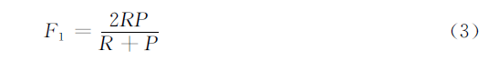

#### 2.5 集成学习模型

集成学习是指通过构建一个新模型，经过适当训练后，将达到预期性能的基学习器的预测结果作为输入，经过线性或非线性运算后最终输出一个概率最大的预测结果。

## 3. 系统整体设计

第一部分以非结构化文本作为输入，经过预处理后形成结构化的词条文档矩阵，然后通过更换特征提取方法和分类器，筛选出达到预期性能的基学习器，同时输出基学习器的判决结果；

第二部分则将基学习器对测试集文本的分类结果作为输入，通过集成学习后，输出对测试集文本的最终判决。

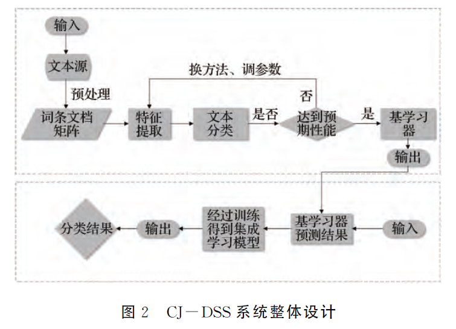

## 4. 实证分析与结果